# Gradient Descent Implementation for a Logistic Regression Model

### Mathematical derivations of logistic loss and its gradient

We seek to find the optimal coefficients $\boldsymbol{\beta} = (\beta_{0}, \dots, \beta_{p})^\mathsf{T}$ that minimizes the negative log-likelihoods with some added positive penalty term $\lambda \in \mathbb{R}$. We decided to go for an L2 (ridge) regularization because of the following reasons:

- We are building a simpler model with fewer predictors and so we ideally do not want them to shrink to zero, which would be the case if we used L1 lasso regularization;
- The presence of slight multicollinearity suggests that ridge regression will outperform lasso regression since it distributes the penalty across the correlated predictors; and
- L2 regularization is mathematically differentiable everywhere since it is a sum of squares whereas L1 uses a sum of absolutes which complicates our analytical solution.

The negative log-likelihoods, also known as the logistic loss, are given by the following equation

$$\ell(\beta \; ; \; y \, \vert \, x) = -\sum_{i=0}^{n} \left [ \, y_{i}
\log(\sigma(x_{i})) + (1 - y_{i}) \log(1 - \sigma(x_{i})) \, \right] +
\lambda \sum_{j=1}^{p} \beta_{j}^{2},$$

where $\sigma(\bullet \; ; \; \beta)$ is given by the logistic function (commonly denoted as the sigmoid function)

$$\sigma(x_{i}) = \frac{1}{1 + e^{-x_{i}\beta}} .$$

We first need to find the gradient of the loss function by computing derivatives

$$\frac{\partial}{\partial \beta} \; \ell(\beta \; ; \; y \, \vert \, x)
= -\sum_{i=0}^{n} \left [ \, y_{i} \frac{1}{\sigma(x_{i})}
\frac{\partial \sigma(x_{i})}{\partial \beta} - (1 - y_{i}) \frac{1}{1 -
\sigma(x_{i})} \frac{\partial (1-\sigma(x_{i}))}{\partial \beta} \,
\right] + 2\lambda\beta.$$

We see that

$$\frac{\partial}{\partial \beta} \; \sigma(x_{i} \; ; \; \beta) =
\frac{\partial}{\partial \beta} \left ( \frac{1}{1 + e^{-x_{i}\beta}}
\right) = \frac{x_{i} e^{-x_{i}\beta}}{(1 + e^{-x_{i}\beta})^{2}} =
\sigma(x_{i})(1-\sigma(x_{i}))x_{i},$$

and so substituting back into the gradient function simplifies the equation to

$$\begin{align}
\frac{\partial}{\partial \beta} \; \ell(\beta \; ; \; y \, \vert \, x)
&= -\sum_{i=0}^{n} \left [ \, y_{i}(1 - \sigma(x_{i}))x_{i} -
(1-y_{i})\sigma(x_{i})x_{i} \, \right] + 2\lambda\beta\\
&=\sum_{i=0}^{n} \left [ \, (\sigma(x_i) - y_{i}) x_{i} \, \right ]
+ 2\lambda\beta.
\end{align}$$

(Notice we distributed the negative in front of the summation through and factored out the $x_{i}$ found in both terms). We define these functions in R for later in the implementation.

### Defining the necessary functions to implement gradient descent

We separate out different components of the gradient descent algorithm in smaller, easier to understand functions. This helps to make the code more readable and easier to debug. We first define the methods `logistic_func`, `logistic_loss`, and `gradients` based on the mathematical derivations found above.

```r
# s-shaped sigmoid function
logistic_func <- function(logits) {
    1/(1 + exp(-logits))
}

# implemented using L2 ridge regularization (note: the intercept term does not get penalized)
logistic_loss <- function(betas, X, y, lambda) {
    # note that `y_hats` are the predicted conditional probabilities having applied the sigmoid function on the design matrix and coefficients product NOT the predicted
    # classes of heart disease presence
    y_hats <- logistic_func(X %*% betas)
    penalty <- lambda * sum(betas[-1] * betas[-1])

    -sum(y * log(y_hats) + (1 - y) * log(1 - y_hats)) + penalty
}

# this function is not a numeric approximation of the gradient but rather the direct analytical
# functional form as derived in the mathematics above
gradients <- function(betas, X, y, lambda) {
    # note that `y_hats` are the predicted conditional probabilities having applied the sigmoid function on the design matrix and coefficients product NOT the predicted
    # classes of heart disease presence
    y_hats <- logistic_func(X %*% betas)

    # separate the logistic and penalty terms to compute gradients easier
    logistic_gradient <- t(X) %*% (y_hats - y)
    penalty_gradient <- 2 * lambda * betas[-1]

    # sum the two components of the gradient while keeping the intercept term non-regularized
    logistic_gradient + c(0, penalty_gradient)
}
```

```r
# format the training dataset by removing the target column, adding an intercept
# column of all 1s, and scaling the inputs before returning it as a matrix
# (necessary for the %*% notation used)
design_matrix <- function(training) {
    training %>%
        select(-c(all_of("target"))) %>%
        mutate(intercept = 1, .before = 1) %>%
        mutate_at(vars(-intercept), scale) %>%
        as.matrix
}

# returns the optimal step size as computed by the Barzilai-Borwein method given
# the current and previous beta and gradient
update_step_size <- function(iteration, betas, gradients) {
    betas_delta <- betas[iteration - 1,] - betas[iteration - 2,]
    gradients_delta <- gradients[iteration - 1,] - gradients[iteration - 2,]

    # we have found that taking long BB step sizes works better for these data
    sum(betas_delta %*% betas_delta) / sum(betas_delta %*% gradients_delta)
}

gradient_descent <- function(training, predictor_names, lambda, tolerance, max_iterations) {
    # format the X and y training values to be of use
    X_training <- design_matrix(training)
    y_training <- training$target

    # randomly sample `p` uniformly-distributed values for the initial coefficients
    # since the inputs are scaled in the range [0,1]
    initial_betas <- runif(ncol(X_training))
    initial_step_size <- runif(1, min = 0.001, max = 0.01)

    # each value is an iteration of updated losses to keep track of its history;
    # the same goes for the step sizes
    losses <- numeric(max_iterations)
    step_sizes <- numeric(max_iterations)

    # each row is an iteration of updated coefficients to keep track of its history;
    # the same goes for the gradients
    betas <- matrix(NA, nrow = max_iterations, ncol = ncol(X_training))
    gradients <- matrix(NA, nrow = max_iterations, ncol = ncol(X_training))

    # save the initial coefficients as the randomly selected ones and manually
    # kickstart the descent algorithm
    betas[1,] <- initial_betas
    gradients[1,] <- gradients(betas[1,], X_training, y_training, lambda)
    step_sizes[1] <- initial_step_size
    losses[1] <- logistic_loss(betas[1,], X_training, y_training, lambda)

    # another iteration of manually computing the descent algorithm to ensure
    # that it is working before looping through
    betas[2,] <- betas[1,] - step_sizes[1] * gradients[1,]
    gradients[2,] <- gradients(betas[2,], X_training, y_training, lambda)
    step_sizes[2] <- initial_step_size
    losses[2] <- logistic_loss(betas[2,], X_training, y_training, lambda)

    for(iteration in 3:max_iterations) {
        previous_beta <- betas[iteration - 1,]
        previous_gradient <- gradients[iteration - 1,]
        previous_step_size <- step_sizes[iteration - 1]

        # compute the optimal step size using the Barzilai-Borwein method and then
        # update the coefficients, gradients, and losses
        step_sizes[iteration] <- update_step_size(iteration, betas, gradients)
        betas[iteration,] <- previous_beta - step_sizes[iteration] * previous_gradient
        gradients[iteration,] <- gradients(betas[iteration,], X_training, y_training, lambda)
        losses[iteration] <- logistic_loss(betas[iteration,], X_training, y_training, lambda)

        # we compute the norm, or size of, the gradient vector using the L2 norm
        # (Euclidean norm) and check if it is reasonably small enough
        if (norm(gradients[iteration,], type = "2") < tolerance) {
            # trim the betas, gradients, losses, and step sizes matrices/vectors
            # as to not have a bunch of trailing zeros or NULL values and then exit
            # the loop
            betas <- betas[1:iteration,]
            gradients <- gradients[1:iteration,]
            losses <- losses[1:iteration]
            step_sizes <- step_sizes[1:iteration]
            break
        }
    }

    # return all of the matrices and vectors used in a R list which will be
    # convenient by using the `$.` notation on the model output
    list(
        coefficients = betas,
        gradients = gradients,
        losses = losses,
        step_sizes = step_sizes,
        predictors = c("(Intercept)", predictor_names)
    )
}
```

### Explanation of why feature scaling was necessary

Note that we scale every column in the input space (besides the intercept and target columns) in the `design_matrix` function. When we ran this gradient descent algorithm on unscaled values the logistic loss broke down after the first few iterations. A deeper examination revealed that the scale of the input values could range from 126–564 mg/dL (in the case of cholesterol) whereas our response is only binary. This size difference meant that $\boldsymbol{X\beta}$ would either produce extremely large or extremely small values which would become numerically unstable once the sigmoid function was applied $\sigma(\boldsymbol{X\beta})$.

Consider if $\sigma(\boldsymbol{X\beta}) = 0$. Then, $\log(\sigma(\boldsymbol{X\beta})) = \log(0)$ which is undefined. Similarly, if $\sigma(\boldsymbol{X\beta}) = 1$ then, $\log(1-\sigma(\boldsymbol{X\beta})) = \log(0)$ which is also undefined. The output of sigmoid being exactly 0 or exactly 1 happens when the result of $\boldsymbol{X\beta}$ is numerically unstable. The `logistic_loss` method would save the current iteration’s loss as `NaN` (not a number) in the losses history every iteration. The `coefficients` and `gradients` contained large vectors meaning the descent jumped around a lot and never converged on the local minima, only stopping due to the `max_iterations` being met.

We scaled down the input space $\boldsymbol{X}$ (besides the intercept and target columns) to combat the numerical instability and our implementation works as expected.

### Simulating training and testing data for a naive model

Before we run our logistic regression gradient descent implementation on our project data we want to assure that it works on simulated data. The following method does this and we show a preview of the generated data as well as the true coefficients.

```r
simulate_data <- function(n_observations = 5000, p_predictors = 10) {
    set.seed(1)

    sparsity <- p_predictors / 2

    nonzero_betas <- runif(sparsity, min = -1, max = 1)
    true_coefficients <- c(.5, nonzero_betas, rep(0, sparsity))

    # we again generate random values from a uniform distribution to match the scale
    # of the inputs of the target dataset
    raw_data <- matrix(
        runif(n_observations * p_predictors),
        ncol = p_predictors
    )

    X_simulated <- cbind(
        rep(1, n_observations),
        raw_data
    )
    y_simulated <- rbinom(
        n = n_observations,
        size = 1,
        prob = logistic_func(X_simulated %*% true_coefficients)
    )

    # create the simulated dataset in the correct format as expected by the gradient
    # descent method; additionally create dummy predictor names using R's default V{1,...,p}
    # undefined column name notation
    simulated_dataset <- cbind(X_simulated[,-1], target = y_simulated) %>% as.data.frame
    predictor_names <- paste0("V", 1:p_predictors)

    set.seed(NULL)

    list(
        data = simulated_dataset,
        true_coefficients = true_coefficients,
        predictors = predictor_names
    )
}

p_predictors <- 4

simulated_training <- simulate_data(n_observations = 2000, p_predictors = p_predictors)
simulated_training$data %>% head
```

|  | V1 | V2 | V3 | V4 | target |
| --- | --- | --- | --- | --- | --- |
| 1 | 0.5728534 | 0.8669163 | 0.02728685 | 0.65047706 | 0 |
| 2 | 0.9082078 | 0.4377153 | 0.49629785 | 0.07465596 | 0 |
| 3 | 0.2016819 | 0.1919378 | 0.94735171 | 0.90258066 | 0 |
| 4 | 0.8983897 | 0.0822944 | 0.38118213 | 0.13293963 | 1 |
| 5 | 0.9446753 | 0.5834516 | 0.69821373 | 0.21082604 | 0 |
| 6 | 0.6607978 | 0.0703615 | 0.68876581 | 0.15516040 | 1 |

```r
simulated_training$true_coefficients %>% print
```

```
## [1]  0.5000000 -0.4689827 -0.2557522  0.0000000  0.0000000
```

We also will define the simulated testing dataset which will be used later to evaluate the naive model later. It is generated in a similar manner to its training counterpart.

```r
simulated_testing <- simulate_data(n_observations = 1000, p_predictors = p_predictors)
simulated_testing$data %>% head
```

|  | V1 | V2 | V3 | V4 | target |
| --- | --- | --- | --- | --- | --- |
| 1 | 0.5728534 | 0.38328339 | 0.8669163 | 0.1774016 | 1 |
| 2 | 0.9082078 | 0.95498800 | 0.4377153 | 0.3971333 | 0 |
| 3 | 0.2016819 | 0.11835658 | 0.1919378 | 0.8142270 | 0 |
| 4 | 0.8983897 | 0.03910006 | 0.0822944 | 0.9413571 | 1 |
| 5 | 0.9446753 | 0.50450503 | 0.5834516 | 0.1733499 | 1 |
| 6 | 0.6607978 | 0.57848256 | 0.0703615 | 0.3549408 | 0 |

```r
simulated_testing$true_coefficients %>% print
```

```
## [1]  0.5000000 -0.4689827 -0.2557522  0.0000000  0.0000000
```

### Creating the naive model and analyzing its outputs

We then now define our naive model by calling our `gradient_descent` implementation on the `simulated_training` object so that we can later visualize how the model performs on the testing stage and, eventually, how it performs on unseen testing data.

```r
naive_model <- gradient_descent(
    simulated_training$data,
    simulated_training$predictors,
    lambda = 1.7,
    tolerance = 1e-5,
    max_iterations = 10000
)
```

We additionally define some methods for understanding the output of our model including a table of coefficients, a plot of losses over iterations, a plot of step sizes over iterations, and a plot of coefficients over iterations.

We can now analyze what the naive model converged on for its coefficients versus the true coefficients by using the `compare_coefficients` method. This function generates a table of true and expected coefficients with a third column being their difference to more easily view how big the difference is.

```r
compare_coefficients <- function(modelA_coefficients, modelB_coefficients, predictors, column_names) {
    # compute the difference in coefficients to more easily see how off our implementation estimates are
    # either in the case of our model versus R's `glm` version or our naive model versus the true
    # coefficients
    difference <- modelA_coefficients - modelB_coefficients

    # assemble the table and make it more readable with meaningful column and row names
    coefficients_comparison <- cbind(modelA_coefficients, modelB_coefficients, difference)
    colnames(coefficients_comparison) <- c(column_names, "difference")
    rownames(coefficients_comparison) <- predictors

    coefficients_comparison
}

naive_coefficients <- naive_model$coefficients[nrow(naive_model$coefficients),]
compare_coefficients(
    modelA_coefficients = naive_coefficients,
    modelB_coefficients = simulated_training$true_coefficients,
    predictors = c("(Intercept)", simulated_training$predictors),
    column_names = c("estimated coef.", "true coef.")
)
```

```
##             estimated coef. true coef.  difference
## (Intercept)      0.11342276  0.5000000 -0.38657724
## V1              -0.15215072 -0.4689827  0.31683195
## V2              -0.14944351 -0.2557522  0.10630869
## V3               0.03573019  0.0000000  0.03573019
## V4              -0.04513723  0.0000000 -0.04513723
```

We can also observe the logistic loss history saved in the `naive_model` object and view it on a plot via the `plot_losses` function. Note that this method accepts a `model_type` parameter which is placed into the plot’s title for clarity so that this function can be used by both the naive and (later) the final models.

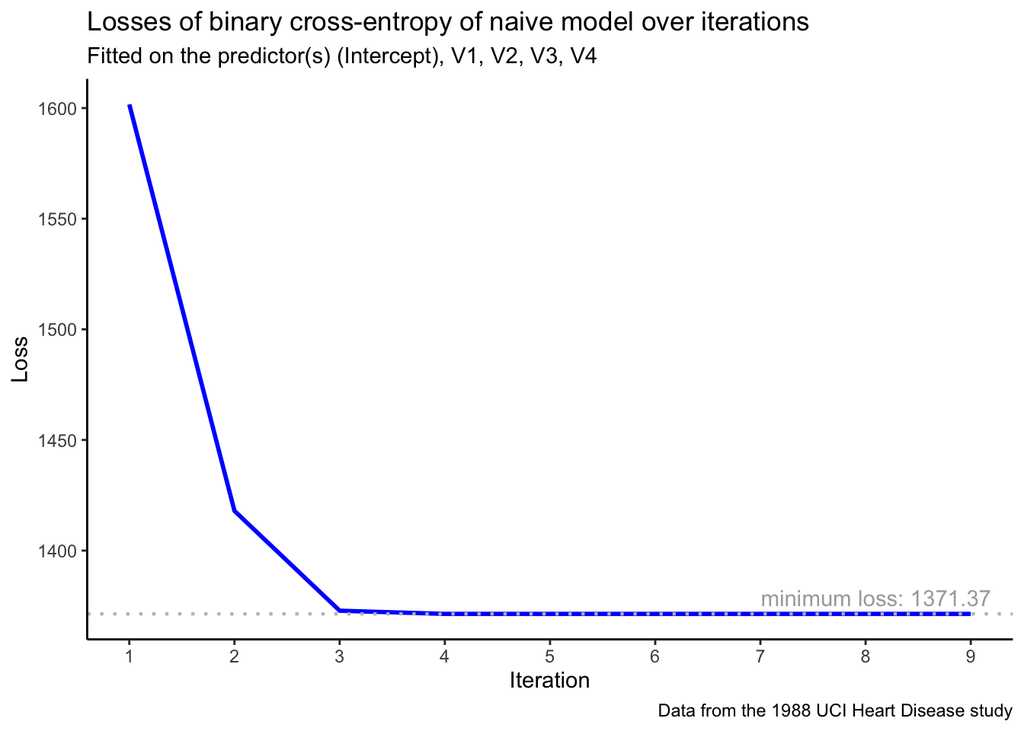

```r
plot_losses <- function(model, model_type = "normal") {
    n_iterations <- length(model$losses)
    min_loss <- min(model$losses)

    ggplot(data.frame(iteration = 1:n_iterations, loss = model$losses)) +
        # connect each loss value per iteration with a solid blue line
        geom_line(aes(x = iteration, y = loss), color = "blue", linewidth = 1) +
        # visibly show where the minimum loss achieved is and add text with the number
        geom_hline(yintercept = min_loss, linetype = "dotted", color = "gray", linewidth = 0.75) +
        annotate("text", x = n_iterations * 0.9, y = min_loss, label = paste("minimum loss:", round(min_loss, 2)), vjust = -0.5, color = "darkgray") +
        scale_x_continuous(
            limits = c(1, n_iterations),
            breaks = c(1:n_iterations)
        ) +
        # we use the parameter `model_type` since we use this same method for both our actual model
        # and the naive model
        labs(
            title = paste("Losses of binary cross-entropy of", model_type, "model over iterations"),
            subtitle = paste("Fitted on the predictor(s)", toString(model$predictors)),
            caption = "Data from the 1988 UCI Heart Disease study"
        ) +
        theme_classic() +
        theme(legend.position = "none") +
        xlab("Iteration") +
        ylab("Loss")
}

plot_losses(model = naive_model, model_type = "naive")
```

We can additionally observe the step sizes history saved in the `naive_model` object and view it on a plot via the `plot_steps` function. It is nearly identical to `plot_losses` but with different labels and verbiage.

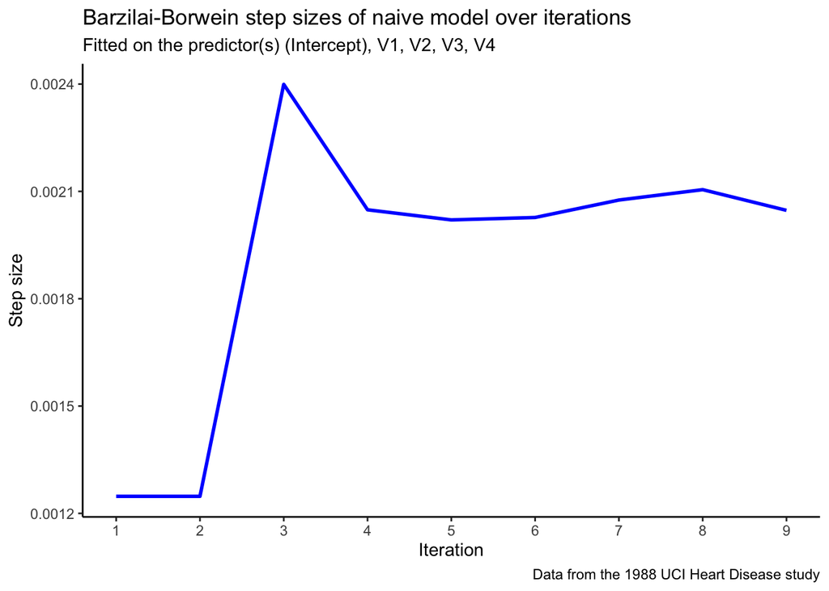

```r
plot_steps <- function(model, model_type = "normal") {
    n_iterations <- length(model$step_sizes)

    ggplot(data.frame(iteration = 1:n_iterations, step = model$step_sizes)) +
        # connect each step size value per iteration with a solid blue line
        geom_line(aes(x = iteration, y = step), color = "blue", linewidth = 1) +
        scale_x_continuous(
            limits = c(1, n_iterations),
            breaks = c(1:n_iterations)
        ) +
        labs(
            title = paste("Barzilai-Borwein step sizes of", model_type, "model over iterations"),
            subtitle = paste("Fitted on the predictor(s)", toString(model$predictors)),
            caption = "Data from the 1988 UCI Heart Disease study"
        ) +
        theme_classic() +
        theme(legend.position = "none") +
        xlab("Iteration") +
        ylab("Step size")
}

plot_steps(model = naive_model, model_type = "naive")
```

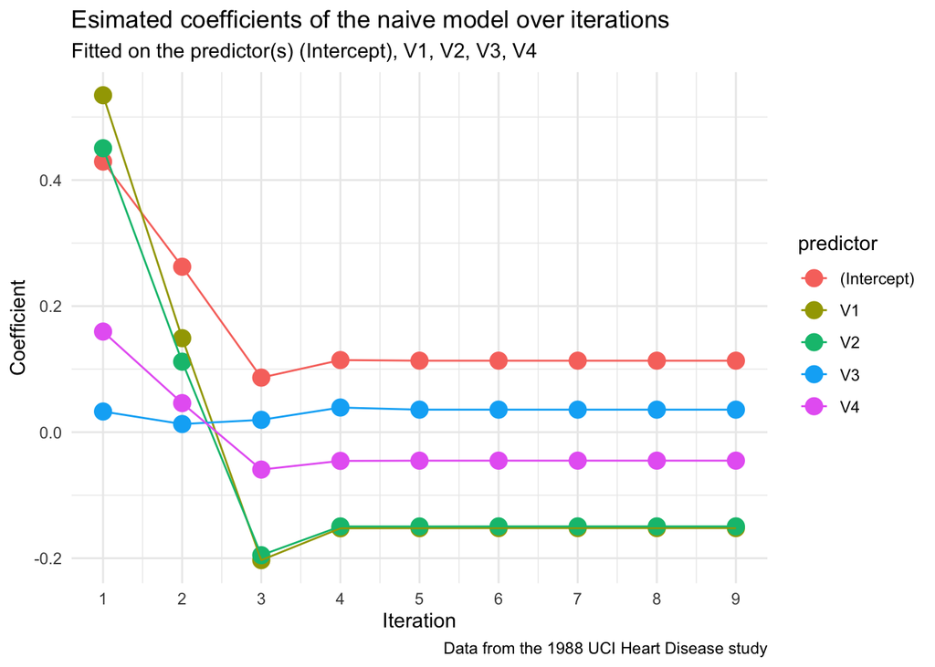

```r
plot_betas <- function(model, model_type = "normal") {
    n_iterations <- nrow(model$coefficients)

    to_plot <- data.frame(
        iteration = c(1:n_iterations),
        coefficient = as.data.frame(model$coefficients)
    )
    colnames(to_plot) <- c("iteration", model$predictors)

    # we re-shape the data so that we can connect each coefficient across iterations AND
    # show all coefficients at each snapshot via pivoting the dataframe longwise
    to_plot <- to_plot %>%
        pivot_longer(cols = -iteration, names_to = "predictor", values_to = "coefficient")

    ggplot(to_plot, aes(x = iteration, y = coefficient, color = predictor)) +
        geom_point(size = 3, stroke = 1.2) +
        geom_line() +
        scale_x_continuous(
            limits = c(1, n_iterations),
            breaks = c(1:n_iterations)
        ) +
        labs(x = "Iteration", y = "Coefficient") +
        labs(
            title = paste("Esimated coefficients of the", model_type, "model over iterations"),
            subtitle = paste("Fitted on the predictor(s)", toString(model$predictors)),
            caption = "Data from the 1988 UCI Heart Disease study"
        ) +
        theme_minimal()
}

plot_betas(model = naive_model, model_type = "naive")
```

We will analyze the metrics of the naive model once we do the same with the normal model and R’s `glm` model. Now we create these model objects and examine the output of the normal model output.

```r
log_model <- gradient_descent(
    training = training,
    predictor_names = predictor_names,
    lambda = 1.7,
    tolerance = 1e-5,
    max_iterations = 10000
)

r_training <- training %>% mutate_at(vars(-target), scale)
r_model <- glm(target ~ ., family = binomial, data = r_training)
```

```r
log_coefficients <- log_model$coefficients[nrow(log_model$coefficients),]
compare_coefficients(
    modelA_coefficients = log_coefficients,
    modelB_coefficients = r_model$coefficients,
    predictors = log_model$predictors,
    column_names = c("model coef.", "R glm coef.")
)
```

```
##             model coef. R glm coef.  difference
## (Intercept)  -0.0619486 -0.07067484 0.008726239
## exang        -0.7773385 -0.80142526 0.024086724
## oldpeak      -0.7434987 -0.77158212 0.028083399
## ca           -0.7936940 -0.82409347 0.030399502
```

To see the significance of the selected predictors in explaining our response, we examine the model output of `glm`. We see from the table below that `exang`, `oldpeak`, and `ca` are all statistically significant quantities.

```r
summary(r_model)
```

```
##
## Call:
## glm(formula = target ~ ., family = binomial, data = r_training)
##
## Coefficients:
##             Estimate Std. Error z value Pr(>|z|)
## (Intercept) -0.07067    0.09547  -0.740    0.459
## exang       -0.80143    0.09763  -8.209 2.24e-16 ***
## oldpeak     -0.77158    0.11373  -6.784 1.17e-11 ***
## ca          -0.82409    0.10510  -7.841 4.47e-15 ***
## ---
## Signif. codes:  0 '***' 0.001 '**' 0.01 '*' 0.05 '.' 0.1 ' ' 1
##
## (Dispersion parameter for binomial family taken to be 1)
##
##     Null deviance: 993.66  on 716  degrees of freedom
## Residual deviance: 700.53  on 713  degrees of freedom
## AIC: 708.53
##
## Number of Fisher Scoring iterations: 5
```

Examining the $p$-values for these coefficients we see that `exang`, `oldpeak`, and `ca` are all statistically significant predictors (all $< 0.5 = \alpha$) in explaining the presence of coronary artery disease.

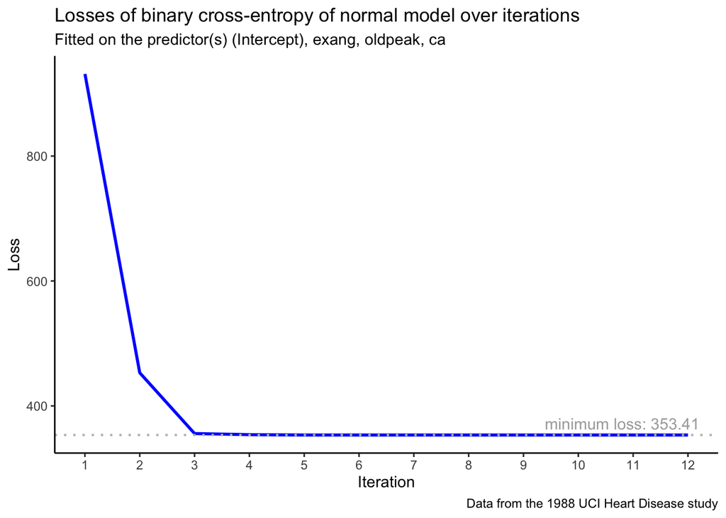

```r
plot_losses(model = log_model, model_type = "normal")
```

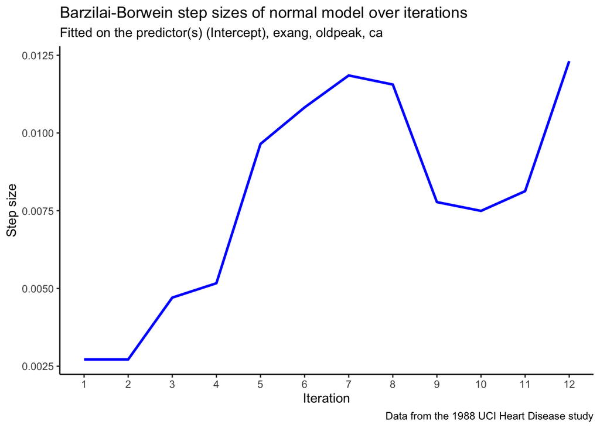

```r
plot_steps(model = log_model, model_type = "normal")
```

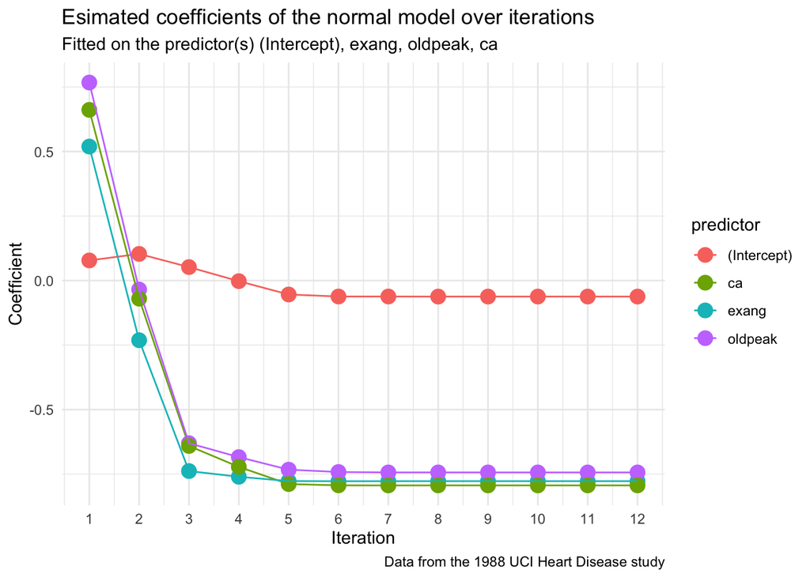

```r
plot_betas(model = log_model, model_type = "normal")
```

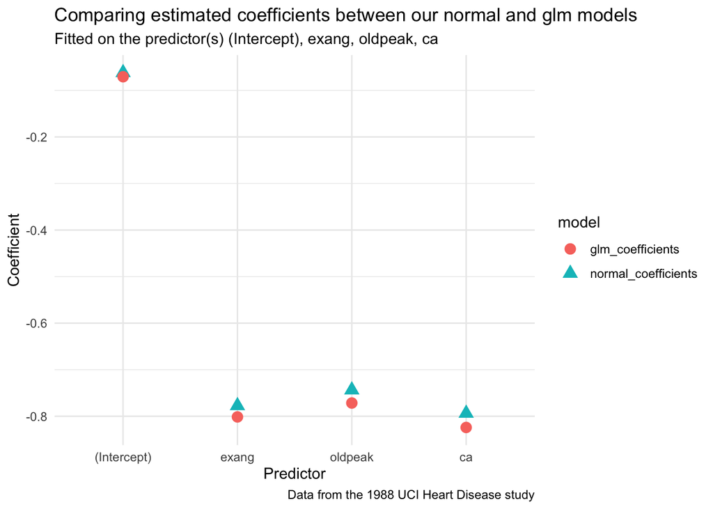

```r
coefficients_comparison <- function(model, r_model) {
    final_coefficients <- model$coefficients[nrow(model$coefficients),]
    r_coefficients <- r_model$coefficients

    predictors <- model$predictors

    to_plot <- data.frame(
        predictor = factor(predictors, levels=predictors),
        normal_coefficients = final_coefficients,
        glm_coefficients = r_coefficients
    ) %>% pivot_longer(
        cols = -predictor,
        names_to = "model",
        values_to = "coefficient"
    )

    ggplot(to_plot, aes(x = predictor, y = coefficient, shape = model, color = model)) +
        geom_point(size = 3, stroke = 1.2) +
        labs(x = "Predictor", y = "Coefficient") +
        labs(title = "Comparing estimated coefficients between our normal and glm models",
                 subtitle = paste("Fitted on the predictor(s)", toString(predictors)),
                 caption = "Data from the 1988 UCI Heart Disease study") +
        theme_minimal()
}

coefficients_comparison(model = log_model, r_model = r_model)
```

From the above plot we see that our normal model and R’s `glm` model have essentially the same coefficients which matches the comparison table seen earlier. On average, our model coefficients are slightly higher than R’s `glm` coefficients but not by a lot as shown by the small scale on the $y$-axis.

We can now analyze the prediction metrics of our model and R’s `glm` model to evaluate their effectiveness as well as compare to our naive model.

We now look at the accuracy and AUC metrics across all three models as summarized in the following table.

```r
all_metrics <- data.frame(
    "training accuracy" = c(
        naive_metrics$training_accuracy,
        log_metrics$training_accuracy,
        r_metrics$training_accuracy
    ),
    "training auc" = c(
        naive_metrics$training_auc,
        log_metrics$training_auc,
        r_metrics$training_auc
    ),
    "testing accuracy" = c(
        naive_metrics$testing_accuracy,
        log_metrics$testing_accuracy,
        r_metrics$testing_accuracy
    ),
    "testing auc" = c(
        naive_metrics$testing_auc,
        log_metrics$testing_auc,
        r_metrics$testing_auc
    )
)

rownames(all_metrics) <- c("naive model", "normal model", "glm model")
colnames(all_metrics) <- c("training accuracy", "training auc", "testing accuracy", "testing auc")

all_metrics
```

|  | training accuracy | training auc | testing accuracy | testing auc |
| --- | --- | --- | --- | --- |
| naive model | 53.75 | 52.68 | 54.60 | 52.4 |
| normal model | 76.29 | 76.17 | 79.55 | 79.4 |
| glm model | 76.29 | 76.17 | 79.55 | 79.4 |

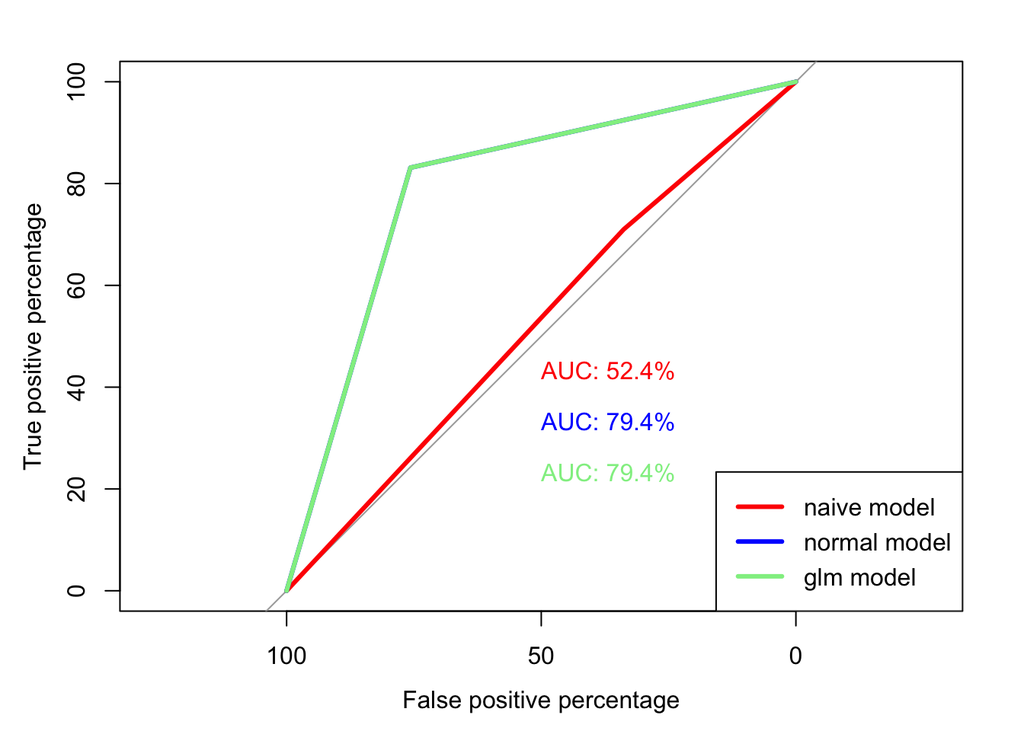

```r
plot_ROC <- function(metrics, curve_color, y_height, add_to = FALSE) {
    # `y_height` is the height where the AUC percentage label is printed so that they do not
    # overlap; `add_to` is needed to overlap the naive, normal, and glm model ROC curves
    roc_object <- roc(
        response = metrics$true_classes_testing,
        predictor = metrics$prediction_classes_testing,
        plot = TRUE,
        percent = TRUE,
        xlab = "False positive percentage",
        ylab = "True positive percentage",
        col = curve_color,
        lwd = 3,
        print.auc = TRUE,
        print.auc.y = y_height,
        add = add_to,
        quiet = TRUE
    )
}

plot_ROC(metrics = naive_metrics, curve_color = "red", y_height = 45, add_to = FALSE)
plot_ROC(metrics = log_metrics, curve_color = "blue", y_height = 35, add_to = TRUE)
plot_ROC(metrics = r_metrics, curve_color = "lightgreen", y_height = 25, add_to = TRUE)

models <- c("naive model", "normal model", "glm model")
colors <- c("red", "blue", "lightgreen")

legend("bottomright", legend = models, col = colors, lwd = 3)
```

The above ROC plot is useful to see visually how the models compare but we would like to see hard values for the true and false positives and negatives across the testing subset for our model. This is done through the confusion matrix shown below.

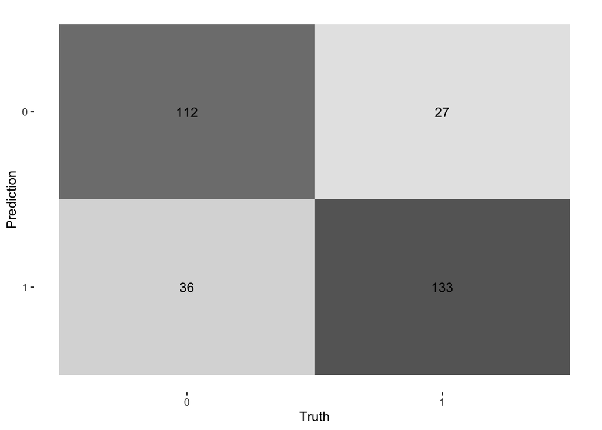

```r
testing_df <- data.frame(
    y = as.factor(testing$target),
    y_hat = as.factor(log_metrics$prediction_classes_testing)
)
confusion_matrix <- testing_df %>%
    conf_mat(truth = y, estimate = y_hat) %>%
    autoplot(type = "heatmap") %>%
    print
```

As we see from the confusion matrix above our model correctly classifies heart disease prevalence the majority of the time, with the the few false negatives and false positives relatively balanced. This suggests that our model performs moderately well on the holdout data which is supported by an AUC score of around 79.4%.